# Exploratory Data Analysis: Home Credit Training Data

Target Variable, Missing Data, Data Quality & Transformation Needs

Author

U6062992, Data Analysis Team

Published

February 11, 2026

```r
library(tidyverse)
library(skimr)

# Load the training data
train <- read_csv("c:/Users/bedna/OneDrive/Documents/home-credit-project/data csv/application_train.csv")

# Load column descriptions
col_desc <- read_csv("c:/Users/bedna/OneDrive/Documents/home-credit-project/data csv/HomeCredit_columns_description.csv")
```

**Note**

The contents have been reviewed and validated by ERIN BEDNARIK, STUDENT on 02/06/2026.

# Business Problem Statement

## Context & Organizational Mission

Many people struggle to obtain home loans due to poor or non-existent credit histories. This market gap has led to an increase in untrustworthy lenders taking advantage of vulnerable populations. **Home Credit** is an organization committed to broadening financial inclusion and access to loans for the unbanked population by providing a positive and safe lending experience.

## The Core Challenge

Home Credit recognizes that traditional credit scores alone cannot tell the complete story of a person’s financial responsibility. Key challenges include:

- **Limited Credit History**: The unbanked population lacks traditional credit records, making assessment with standard methods difficult and often impossible
- **Risk Management Complexity**: Those with poor credit have demonstrated difficulty with repayment; those with no credit history present unknown behavioral risk
- **Fairness & Inclusion**: One financial emergency or poor decision can permanently damage credit, even for otherwise responsible individuals. Yet lending to uncertain applicants carries portfolio risk
- **Need for Model Precision**: Over-approving increases portfolio default risk; over-rejecting limits financial inclusion and misses creditworthy applicants

## Business Objective

Home Credit seeks to develop a **highly accurate predictive model** to estimate the probability that loan applicants will experience repayment difficulties within the first year of loan issuance. This model will enable:

1. **Informed Approvals**: Identify creditworthy applicants with limited or non-traditional credit histories, supporting financial inclusion without increasing portfolio risk
2. **Transparent Risk Assessment**: Enable consistent, data-driven risk segmentation at loan approval time with clear business logic
3. **Targeted Support**: Identify applicants unlikely to succeed with loan payments, allowing proactive offer of alternative resources or support programs

## Success Metrics

Model success will be measured using business-aligned credit risk metrics:

- **ROC-AUC**: Improved borrower risk separation, accounting for the imbalanced nature of default events
- **Repayment Performance**: Stable or improved first-year repayment performance among newly approved loans

## Analytical Approach

This project develops a **binary classification model** to predict the probability that a loan applicant will experience repayment difficulties within the first year. The model integrates:

- Traditional credit variables
- Alternative behavioral and historical loan data
- Emphasis on model interpretability and business usability to support credit officers and executives

**Scope**: First-year default prediction for loan applicants  
**Out of Scope**: Long-term (15–30 year) prediction; post-approval interventions  
**Constraints**: Fair lending compliance; ethical use of alternative data; model transparency

# Executive Summary

This EDA covers the Home Credit application training dataset with **307511** records and **122** features. The analysis focuses on four key areas critical to building an effective default risk model:

1. **Target Variable**: Significantly imbalanced (~8% positive class) — requires careful handling to prevent model bias toward the majority class
2. **Missing Data**: Extensive missing values in building/property features (~67-70%) — impacts feature availability and imputation strategy
3. **Data Quality Issues**: Anomalies in employment days, outliers in financial metrics — requires investigation and cleaning before modeling
4. **Transformation Needs**: Log transformations for skewed distributions, feature engineering opportunities — essential for improving model performance

# 1. Target Variable Analysis

## 1.1 Class Distribution

The target variable indicates whether a client experienced payment difficulties (1 = Yes, 0 = No) within the first year of loan issuance—the exact outcome we seek to predict.

```r
# Determine the value and percentage of distribution of the target variable.
target_dist <- train |>
  count(TARGET) |>
  mutate(
    pct = n / sum(n) * 100,
    label = c("No Difficulties", "Has Difficulties")
  )

target_dist
```

```
# A tibble: 2 × 4
  TARGET      n   pct label
   <dbl>  <int> <dbl> <chr>
1      0 282686 91.9  No Difficulties
2      1  24825  8.07 Has Difficulties
```

**Key Finding**: The dataset is **heavily imbalanced** with only **8.07%** positive cases (payment difficulties). This 11:1 imbalance will require careful consideration when modeling to avoid bias toward predicting the majority class.

## 1.2 Target Distribution Visualization

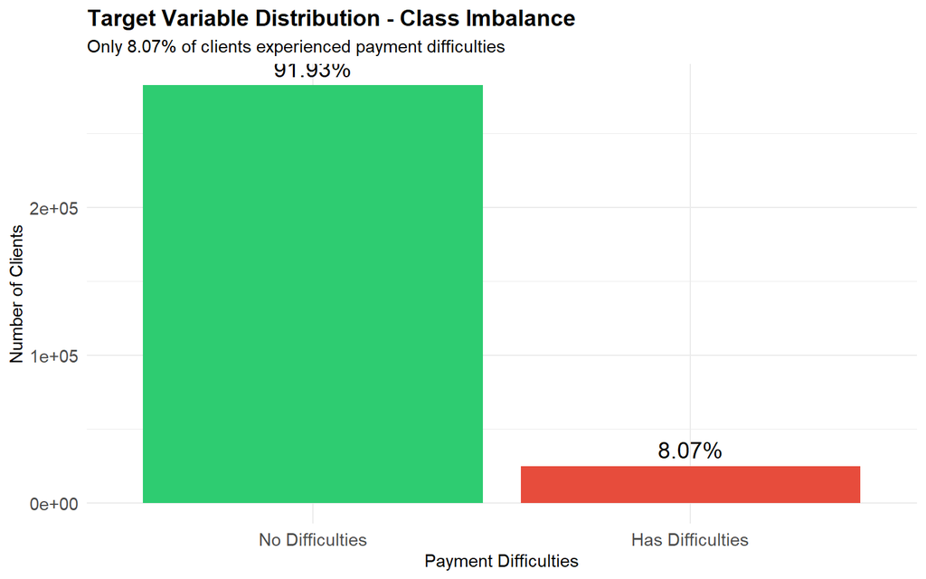

```r
# Produce visualization of the target variable distribution.
target_dist |>
  ggplot(aes(x = fct_reorder(label, TARGET), y = n, fill = factor(TARGET))) +
  geom_col(show.legend = FALSE) +
  geom_text(aes(label = paste0(pct |> round(2), "%")), vjust = -0.5, size = 5) +
  labs(
    title = "Target Variable Distribution - Class Imbalance",
    x = "Payment Difficulties",
    y = "Number of Clients",
    subtitle = "Only 8.07% of clients experienced payment difficulties"
  ) +
  scale_fill_manual(values = c("#2ecc71", "#e74c3c")) +
  theme_minimal() +
  theme(
    plot.title = element_text(size = 14, face = "bold"),
    axis.text.y = element_text(size = 11),
    axis.text.x = element_text(size = 11)
  )
```

# 2. Missing Data Analysis

## 2.1 Overall Missing Data Summary

```r
# Calculate missing data summary for each column and categorize by severity
missing_summary <- train |>
  summarise(across(everything(), ~sum(is.na(.)))) |>
  pivot_longer(everything(), names_to = "column", values_to = "missing_count") |>
  mutate(
    missing_pct = round(missing_count / nrow(train) * 100, 2),
    missing_threshold = case_when(
      missing_pct == 0 ~ "No Missing",
      missing_pct < 5 ~ "Low (< 5%)",
      missing_pct < 50 ~ "Medium (5-50%)",
      missing_pct >= 50 ~ "High (≥ 50%)"
    )
  ) |>
  arrange(desc(missing_pct))

missing_by_threshold <- missing_summary |>
  group_by(missing_threshold) |>
  summarise(n_columns = n(), .groups = "drop")
missing_by_threshold
```

```
# A tibble: 4 × 2
  missing_threshold n_columns
  <chr>                 <int>
1 High (≥ 50%)             41
2 Low (< 5%)                7
3 Medium (5-50%)           16
4 No Missing               58
```

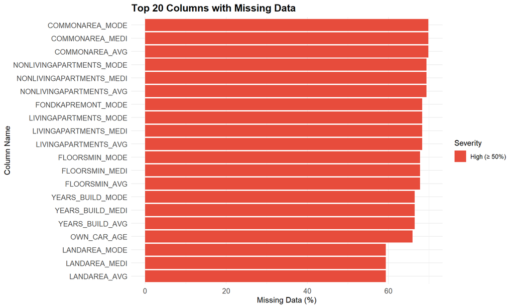

```r
# Visualize missing data percentages by column, highlighting severity thresholds

# Columns with most missing data
missing_top <- missing_summary |> filter(missing_count > 0) |> head(20)

missing_top |>
  ggplot(aes(x = reorder(column, missing_pct), y = missing_pct, fill = missing_threshold)) +
  geom_col(show.legend = TRUE) +
  coord_flip() +
  labs(
    title = "Top 20 Columns with Missing Data",
    x = "Column Name",
    y = "Missing Data (%)",
    fill = "Severity"
  ) +
  scale_fill_manual(values = c("No Missing" = "#27ae60", "Low (< 5%)" = "#f39c12",
                               "Medium (5-50%)" = "#e67e22", "High (≥ 50%)" = "#e74c3c")) +
  theme_minimal() +
  theme(
    plot.title = element_text(size = 14, face = "bold"),
    axis.text = element_text(size = 10)
  )
```

## 2.2 Detailed Missing Data Analysis

```r
# Provide detailed analysis of missing data by severity category, including counts and examples of columns in each category.

# High missing (>50%)
high_missing <- missing_summary |>
  filter(missing_pct >= 50) |>
  select(column, missing_count, missing_pct)

cat("COLUMNS WITH HIGH MISSING DATA (≥50%):\n")
```

```
COLUMNS WITH HIGH MISSING DATA (≥50%):
```

```r
cat("Count:", nrow(high_missing), "columns\n\n")
```

```
Count: 41 columns
```

```r
head(high_missing, 10)
```

```
# A tibble: 10 × 3
   column                   missing_count missing_pct
   <chr>                            <int>       <dbl>
 1 COMMONAREA_AVG                  214865        69.9
 2 COMMONAREA_MODE                 214865        69.9
 3 COMMONAREA_MEDI                 214865        69.9
 4 NONLIVINGAPARTMENTS_AVG         213514        69.4
 5 NONLIVINGAPARTMENTS_MODE        213514        69.4
 6 NONLIVINGAPARTMENTS_MEDI        213514        69.4
 7 FONDKAPREMONT_MODE              210295        68.4
 8 LIVINGAPARTMENTS_AVG            210199        68.4
 9 LIVINGAPARTMENTS_MODE           210199        68.4
10 LIVINGAPARTMENTS_MEDI           210199        68.4
```

```r
# Medium missing (5-50%)
med_missing <- missing_summary |>
  filter(missing_pct >= 5 & missing_pct < 50) |>
  select(column, missing_count, missing_pct)

cat("\n\nCOLUMNS WITH MEDIUM MISSING DATA (5-50%):\n")
```

```
COLUMNS WITH MEDIUM MISSING DATA (5-50%):
```

```r
cat("Count:", nrow(med_missing), "columns\n\n")
```

```
Count: 16 columns
```

```r
head(med_missing, 10)
```

```
# A tibble: 10 × 3
   column                       missing_count missing_pct
   <chr>                                <int>       <dbl>
 1 FLOORSMAX_AVG                       153020        49.8
 2 FLOORSMAX_MODE                      153020        49.8
 3 FLOORSMAX_MEDI                      153020        49.8
 4 YEARS_BEGINEXPLUATATION_AVG         150007        48.8
 5 YEARS_BEGINEXPLUATATION_MODE        150007        48.8
 6 YEARS_BEGINEXPLUATATION_MEDI        150007        48.8
 7 TOTALAREA_MODE                      148431        48.3
 8 EMERGENCYSTATE_MODE                 145755        47.4
 9 OCCUPATION_TYPE                      96391        31.4
10 EXT_SOURCE_3                         60965        19.8
```

## 2.3 Missing Data Solutions

[output not shown]

# 3. Data Quality Issues & Anomalies

## 3.1 Key Data Quality Problems

### 3.1.1 DAYS_EMPLOYED Anomaly

```r
# DAYS_EMPLOYED is intended to represent the number of days since employment start (negative values). However, there are records with positive values, which is a data quality issue.

# Check DAYS_EMPLOYED
employed_check <- train |>
  select(DAYS_EMPLOYED) |>
  arrange(desc(DAYS_EMPLOYED)) |>
  head(10)

cat("Top values in DAYS_EMPLOYED (should all be negative):\n")
```

```
Top values in DAYS_EMPLOYED (should all be negative):
```

```r
employed_check
```

```
# A tibble: 10 × 1
   DAYS_EMPLOYED
           <dbl>
 1        365243
 2        365243
 3        365243
 4        365243
 5        365243
 6        365243
 7        365243
 8        365243
 9        365243
10        365243
```

```r
# Count unusual values
unusual_employed <- train |>
  filter(DAYS_EMPLOYED > 0) |>
  nrow()

cat("\n\nCount of POSITIVE DAYS_EMPLOYED values:", unusual_employed)
```

```
Count of POSITIVE DAYS_EMPLOYED values: 55374
```

```r
cat("\nPercentage:", round(unusual_employed/nrow(train)*100, 2), "%")
```

```
Percentage: 18.01 %
```

```r
# Statistics
cat("\n\nDAYS_EMPLOYED Statistics:")
```

```
DAYS_EMPLOYED Statistics:
```

```r
cat("\nMin:", min(train$DAYS_EMPLOYED))
```

```
Min: -17912
```

```r
cat("\nMax:", max(train$DAYS_EMPLOYED))
```

```
Max: 365243
```

```r
cat("\nMedian:", median(train$DAYS_EMPLOYED))
```

```
Median: -1213
```

**Solution**: Likely these represent clients still employed or a data encoding issue. Investigate further or flag as a separate category.

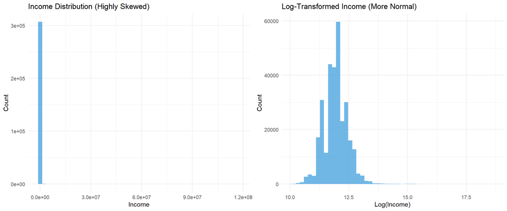

```r
# Visualize the distribution of AMT_INCOME_TOTAL and AMT_CREDIT to identify skewness and outliers.

p1 <- train |>
  ggplot(aes(x = AMT_INCOME_TOTAL)) +
  geom_histogram(bins = 50, fill = "#3498db", alpha = 0.7) +
  labs(title = "Income Distribution (Highly Skewed)",
       x = "Income", y = "Count") +
  theme_minimal()

p2 <- train |>
  ggplot(aes(x = log(AMT_INCOME_TOTAL))) +
  geom_histogram(bins = 50, fill = "#3498db", alpha = 0.7) +
  labs(title = "Log-Transformed Income (More Normal)",
       x = "Log(Income)", y = "Count") +
  theme_minimal()

gridExtra::grid.arrange(p1, p2, ncol = 2)
```

### 3.1.3 Financial Consistency Check

```r
# Check for consistency between AMT_CREDIT, AMT_INCOME_TOTAL, and AMT_ANNUITY. Identify extreme credit-to-income ratios.

# Credit amount vs income ratio
train_check <- train |>
  mutate(
    credit_income_ratio = AMT_CREDIT / AMT_INCOME_TOTAL,
    high_ratio = credit_income_ratio > 10
  ) |>
  select(AMT_INCOME_TOTAL, AMT_CREDIT, AMT_ANNUITY, credit_income_ratio, high_ratio)

cat("Credit-to-Income Ratio Statistics:\n")
```

```
Credit-to-Income Ratio Statistics:
```

```r
cat("Mean:", mean(train_check$credit_income_ratio) |> round(2))
```

```
Mean: 3.96
```

```r
cat("\nMedian:", median(train_check$credit_income_ratio) |> round(2))
```

```
Median: 3.27
```

```r
cat("\nMax:", max(train_check$credit_income_ratio) |> round(2))
```

```
Max: 84.74
```

```r
cat("\nRecords with ratio > 10:", sum(train_check$high_ratio))
```

```
Records with ratio > 10: 9844
```

```r
cat("\nPercentage:", round(sum(train_check$high_ratio)/nrow(train)*100, 2), "%")
```

```
Percentage: 3.2 %
```

```r
# Show extreme cases
cat("\n\nExtreme Cases (Credit > 10x Income):\n")
```

```
Extreme Cases (Credit > 10x Income):
```

```r
train_check |>
  filter(high_ratio) |>
  arrange(desc(credit_income_ratio)) |>
  head(5) |>
  select(-high_ratio)
```

```
# A tibble: 5 × 4
  AMT_INCOME_TOTAL AMT_CREDIT AMT_ANNUITY credit_income_ratio
             <dbl>      <dbl>       <dbl>               <dbl>
1            25650    2173500      48118.                84.7
2            45000    2215224      58568.                49.2
3            45000    1800000      62698.                40
4            58500    2146500      51340.                36.7
5            40500    1436850      42142.                35.5
```

**Finding**: Most clients have reasonable credit-to-income ratios (~3), but 9844 cases have credit amounts > 10x income, which may indicate data errors or special loan types (e.g., mortgages).

### 3.1.4 Children Count Anomaly

```r
# Check the distribution of CNT_CHILDREN to identify any unrealistic values.
train |>
  count(CNT_CHILDREN) |>
  arrange(desc(n))
```

```
# A tibble: 15 × 2
   CNT_CHILDREN      n
          <dbl>  <int>
 1            0 215371
 2            1  61119
 3            2  26749
 4            3   3717
 5            4    429
 6            5     84
 7            6     21
 8            7      7
 9           14      3
10            8      2
11            9      2
12           10      2
13           12      2
14           19      2
15           11      1
```

## 3.2 Age Analysis

```r
# Convert DAYS_BIRTH to age in years and analyze the distribution, checking for unrealistic ages.

train_age <- train |>
  mutate(age_years = -DAYS_BIRTH / 365.25) |>
  select(age_years)

cat("Age Statistics:\n")
```

```
Age Statistics:
```

```r
cat("Min:", min(train_age$age_years) |> round(2), "years")
```

```
Min: 20.5 years
```

```r
cat("\nMax:", max(train_age$age_years) |> round(2), "years")
```

```
Max: 69.07 years
```

```r
cat("\nMedian:", median(train_age$age_years) |> round(2), "years")
```

```
Median: 43.12 years
```

```r
cat("\nMean:", mean(train_age$age_years) |> round(2), "years")
```

```
Mean: 43.91 years
```

```r
# Check for unrealistic ages
young <- train_age |> filter(age_years < 20) |> nrow()
old <- train_age |> filter(age_years > 100) |> nrow()
cat("\n\nClients < 20 years old:", young)
```

```
Clients < 20 years old: 0
```

```r
cat("\nClients > 100 years old:", old)
```

```
Clients > 100 years old: 0
```

# 4. Categorical Variables

## 4.1 Key Categorical Features

```r
# Identify key categorical variables and summarize their distributions, focusing on demographic and contract-related features.

categorical_cols <- train |> select(where(is.character)) |> colnames()

# Focus on key demographic variables
key_cat <- c("NAME_CONTRACT_TYPE", "CODE_GENDER", "FLAG_OWN_CAR", "FLAG_OWN_REALTY",
             "NAME_INCOME_TYPE", "NAME_EDUCATION_TYPE", "NAME_FAMILY_STATUS")

for (col in key_cat) {
  if (col %in% colnames(train)) {
    cat("\n\n", col, ":\n")
    train |>
      count(!!sym(col)) |>
      arrange(desc(n)) |>
      print()
  }
}
```

```
 NAME_CONTRACT_TYPE :
# A tibble: 2 × 2
  NAME_CONTRACT_TYPE      n
  <chr>               <int>
1 Cash loans         278232
2 Revolving loans     29279


 CODE_GENDER :
# A tibble: 3 × 2
  CODE_GENDER      n
  <chr>        <int>
1 F           202448
2 M           105059
3 XNA              4


 FLAG_OWN_CAR :
# A tibble: 2 × 2
  FLAG_OWN_CAR      n
  <chr>         <int>
1 N            202924
2 Y            104587


 FLAG_OWN_REALTY :
# A tibble: 2 × 2
  FLAG_OWN_REALTY      n
  <chr>            <int>
1 Y               213312
2 N                94199


 NAME_INCOME_TYPE :
# A tibble: 8 × 2
  NAME_INCOME_TYPE          n
  <chr>                 <int>
1 Working              158774
2 Commercial associate  71617
3 Pensioner             55362
```

[output cut: 13 more lines]

```
3 Incomplete higher              10277
4 Lower secondary                 3816
5 Academic degree                  164


 NAME_FAMILY_STATUS :
# A tibble: 6 × 2
  NAME_FAMILY_STATUS        n
  <chr>                 <int>
1 Married              196432
2 Single / not married  45444
3 Civil marriage        29775
4 Separated             19770
5 Widow                 16088
6 Unknown                   2
```

## 4.2 Contract Type and Target Relationship

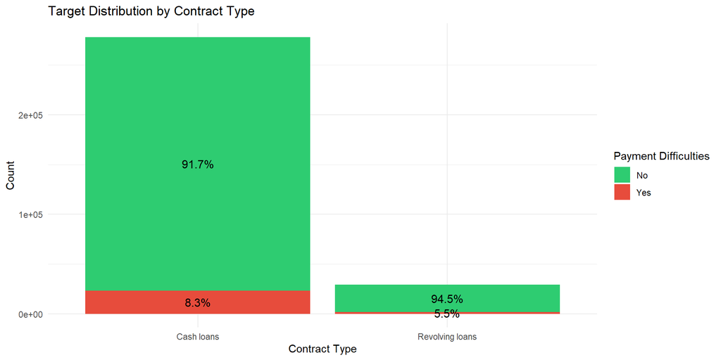

```r
# Analyze the relationship between contract type and the target variable to identify if certain contract types are more associated with payment difficulties.

contract_target <- train |>
  count(NAME_CONTRACT_TYPE, TARGET) |>
  group_by(NAME_CONTRACT_TYPE) |>
  mutate(pct = n / sum(n) * 100)

ggplot(contract_target, aes(x = NAME_CONTRACT_TYPE, y = n, fill = factor(TARGET))) +
  geom_col() +
  geom_text(aes(label = paste0(pct |> round(1), "%")),
            position = position_stack(vjust = 0.5), size = 4) +
  labs(title = "Target Distribution by Contract Type",
       x = "Contract Type", y = "Count", fill = "Payment Difficulties") +
  scale_fill_manual(values = c("#2ecc71", "#e74c3c"), labels = c("No", "Yes")) +
  theme_minimal()
```

# 5. Feature Engineering & Transformation Recommendations

## 5.1 Features Requiring Transformation

[output not shown]

## 5.2 Feature Engineering Opportunities

```r
# Create new features based on domain knowledge and data insights, such as financial ratios, age in years, and indicators for missing building information.

# Example transformations
engineered <- train |>
  slice_head(n = 10) |>
  mutate(
    age_years = -DAYS_BIRTH / 365.25,
    log_income = log(AMT_INCOME_TOTAL + 1),
    log_credit = log(AMT_CREDIT + 1),
    credit_income_ratio = AMT_CREDIT / AMT_INCOME_TOTAL,
    annuity_income_ratio = AMT_ANNUITY / AMT_INCOME_TOTAL,
    has_building_info = !is.na(APARTMENTS_AVG),
    has_ext_source = !is.na(EXT_SOURCE_1) | !is.na(EXT_SOURCE_2) | !is.na(EXT_SOURCE_3)
  ) |>
  select(age_years, log_income, log_credit, credit_income_ratio, annuity_income_ratio,
         has_building_info, has_ext_source)

cat("Example Feature Engineering:\n")
```

```
Example Feature Engineering:
```

```r
head(engineered, 5)
```

```
# A tibble: 5 × 7
  age_years log_income log_credit credit_income_ratio annuity_income_ratio
      <dbl>      <dbl>      <dbl>               <dbl>                <dbl>
1      25.9       12.2       12.9                2.01                0.122
2      45.9       12.5       14.1                4.79                0.132
3      52.1       11.1       11.8                2                   0.1
4      52.0       11.8       12.7                2.32                0.220
5      54.6       11.7       13.1                4.22                0.180
# ℹ 2 more variables: has_building_info <lgl>, has_ext_source <lgl>
```

# 6. Data Cleaning Roadmap

## Priority Actions

7. **Create time features from temporal variables**
   - Day of week effects from `WEEKDAY_APPR_PROCESS_START`
   - Hour of day effects from `HOUR_APPR_PROCESS_START`

# 7. Summary of Data Quality Issues

| Issue | Severity | Impact | Recommended Action |
| --- | --- | --- | --- |
| Class Imbalance | High | Model bias toward majority class | Use class weights, stratified sampling, SMOTE |
| High Missing Data | High | Loss of information, model instability | Drop high-missing columns; impute medium-missing; create indicators |
| DAYS_EMPLOYED Anomaly | Medium | Data quality issue, interpretation problems | Investigate values > 0; separate category or flag |
| Income/Credit Skew | Medium | Model assumptions violated | Log transformation |
| Extreme Ratios | Low | Data entry errors | Identify and flag or remove |
| Outliers | Low | Model instability | Log transform or cap at percentiles |

# 8. Next Steps

1. **Implement cleaning pipeline** based on the roadmap above
2. **Validate transformations** with visualization and statistical tests
3. **Create feature set** for modeling (handle missing data strategically)
4. **Check correlations** between features and target
5. **Prepare for modeling** with appropriate preprocessing using class-balanced techniques

## 9. Conclusion/Results

This EDA has identified important data quality issues, missing data patterns, and transformation needs in the Home Credit training dataset. Key points include: inequitable class distribution, extensive missing data in building features, anomalies in employment days, and skewed financial variables. The EDA has created a foundation for the Home Credit project. By using AI, I can identify patterns, gaps in data, ect more comprehensively and efficiently than myself. The Databot also provided me with suggestions on how to approach the data quality and cleaning process, which will positively impact the next steps of this project.